# VegVault database

Author

Ondřej Mottl

Published

September 3, 2024

# Section I: Description of VegVault

**VegVault** is a SQLite interdisciplinary database linking plot-based vegetation data with functional traits and climate. Specifically, it contains:

- current vegetation plot data
- past vegetation plot data (fossil pollen records)
- functional trait data
- current abiotic data (climate, soil)
- past abiotic data (climate)

# Section II: Overview of VegVault 1.0.0

The database is structured in several logical levels, such as `Dataset`, `Sample`, `Taxa`, `Trait`, etc.

## Dataset

`Dataset` represents the highest levels in the hierarchy. It is the main keystone in the VegVault structure.

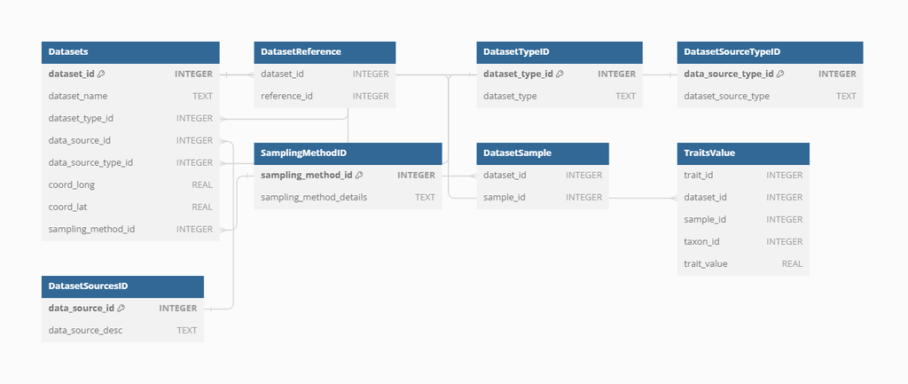

### Dataset Type

`dataset_type_id` defines the basic type of a dataset. This is the highest level of classification of the data

Currently, there **VegVault** consist of those types:

- **vegetation_plot** - current vegetation plot dataset
- **fossil_pollen_archive** - past vegetation plot dataset
- **traits** - dataset containing functional traits
- **gridpoints** - artificially created dataset to hold abiotic data

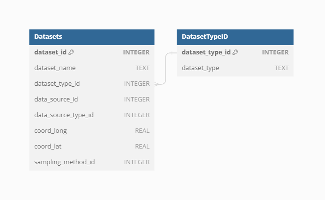

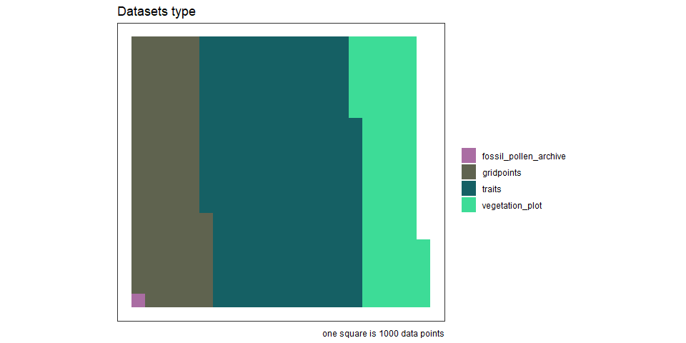

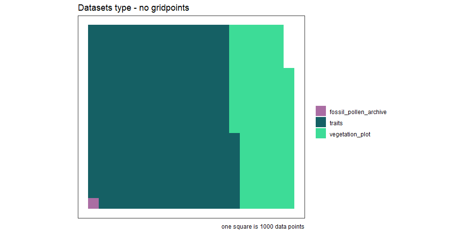

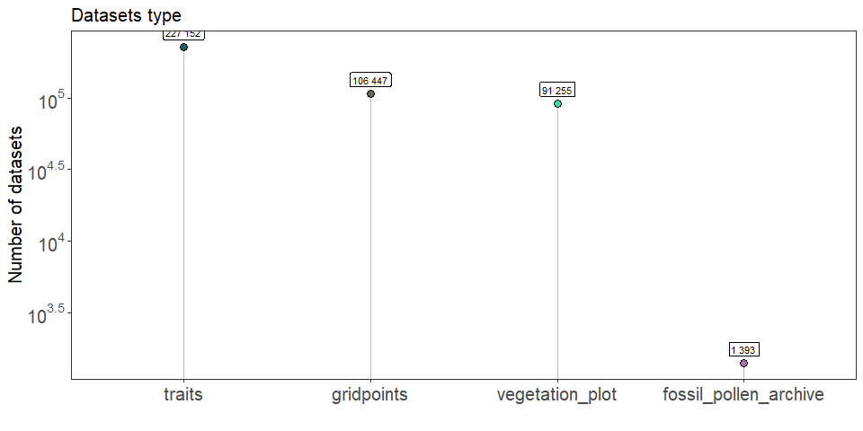

### Dataset Source-Type

`dataset_source_type_id` defines the general provider of the dataset. This should help to classify, which data pipeline was used to import the dataset into the **VegVault**, This is also the first general point of reference of data, as all large databases have a citation statement.

Currently, the **VegVault** consist of those source-types:

- **BIEN** - [Botanical Information and Ecology Network](https://bien.nceas.ucsb.edu/bien/)
- **sPlotOpen** - [The open-access version of sPlot](https://idiv-biodiversity.de/en/splot/splotopen.html)
- **TRY** - [TRY Plant Trait Database](https://www.try-db.org/TryWeb/Home.php)
- **FOSSILPOL** - [The workflow that aims to process and standardise global palaeoecological pollen data](https://hope-uib-bio.github.io/FOSSILPOL-website/)
- **gridpoints** - artificially created dataset to hold abiotic data

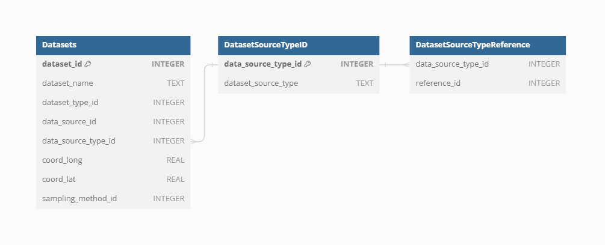

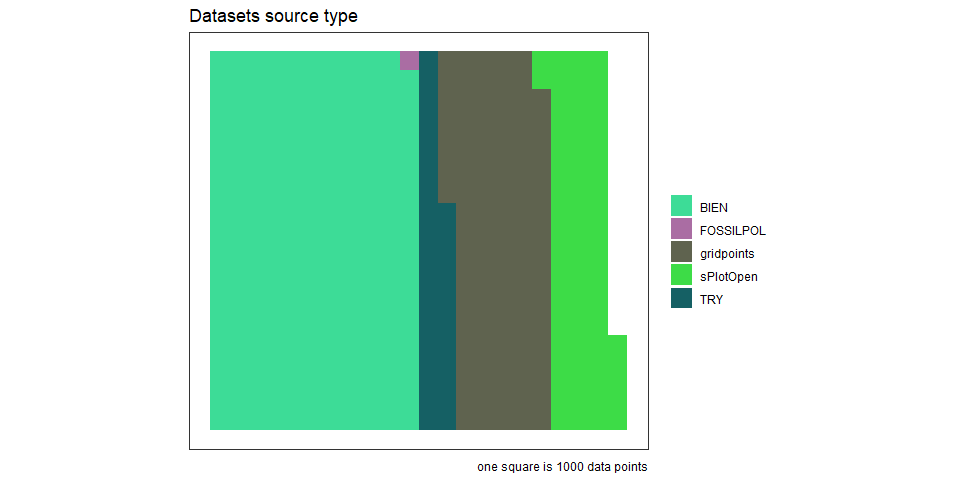

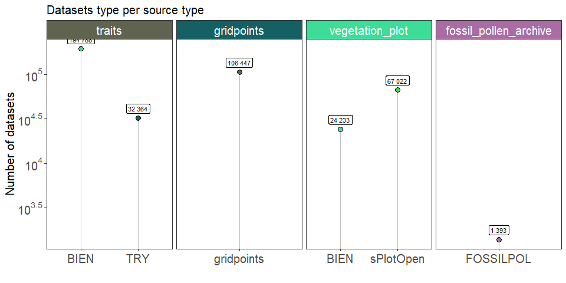

### Dataset Source

Each individual dataset from a specific *Data Source-Type* can have information on the source of the data (i.e. sub-database). This should help to promote better findability of the primary source of data and referencing.

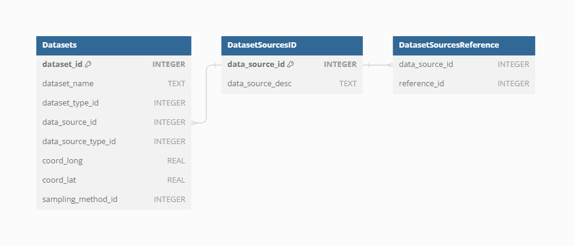

Currently, there are 706 sources of datasets.

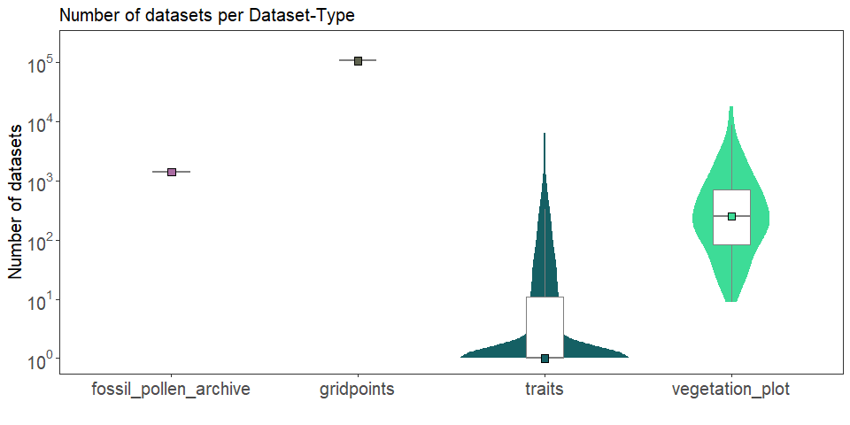

### Sampling method

Some datasets may differ in the way they have been sampled. This could be represented by different ways vegetation data have been sampled for *Dataset Type* of `vegetation_plot`, or depositional environment for *Dataset Type* of `fossil_pollen_archive`.

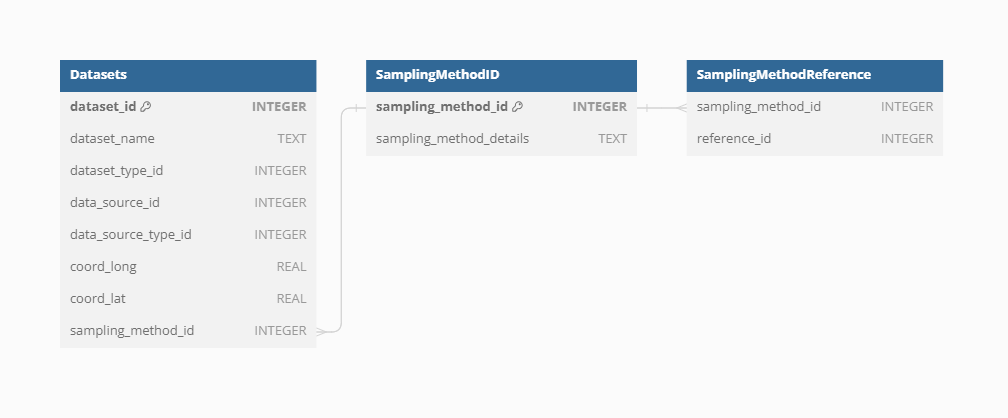

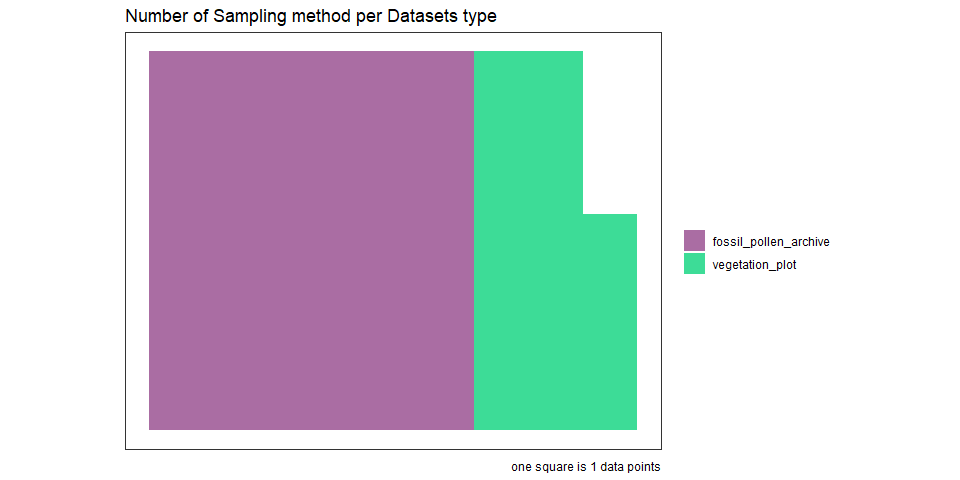

### References

*Dataset Source-Type*, *Dataset Source*, and *Sampling Method* can have their own references. Moreover, each dataset can have one or more references directly to that specific data.

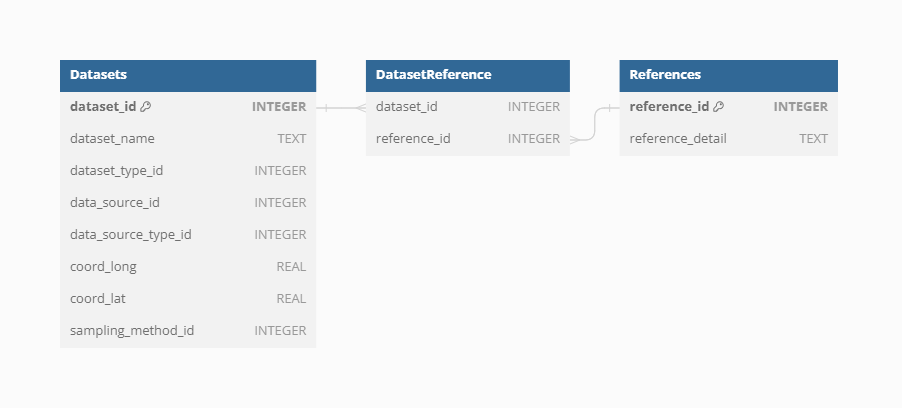

This means that one dataset can have one/several references from each of those parts. Let’s take a look at an example, of what that could mean in practice.

We have selected dataset ID: 91256, which is a fossil pollen archive. Therefore, it has the reference of the *Dataser Source-Type*: *https://doi.org/10.1111/geb.13693* and reference for the individual dataset: *Grimm, E.C., 2008. Neotoma: an ecosystem database for the Pliocene, Pleistocene, and Holocene. Illinois State Museum Scientific Papers E Series, 1.*

## Samples

`Sample` represents the main unit of data in the **VegVault** database.

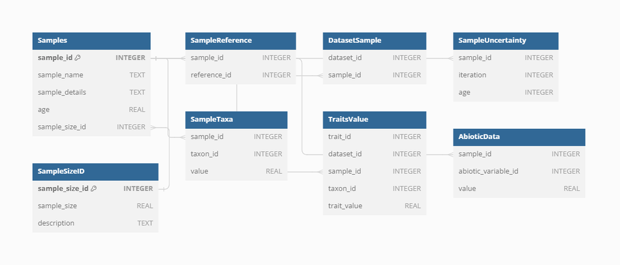

### Dataset-Sample

First `Samples` are linked to `Datasets` via the `Dataset-Sample` table.

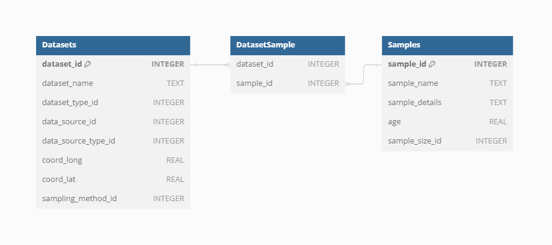

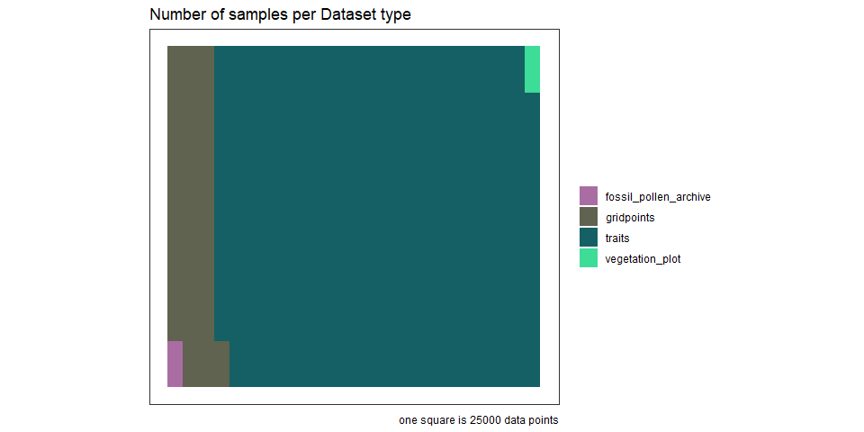

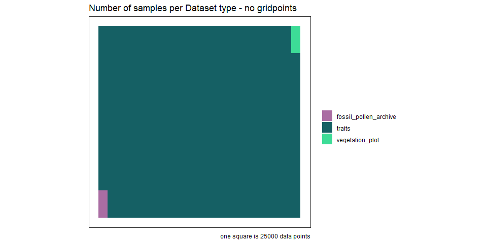

### Sample-size

Vegetation plots can have different sizes, which can have a huge impact on analyses. Therefore, the information about the plot is saved separately.

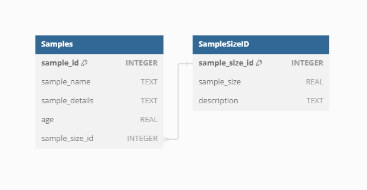

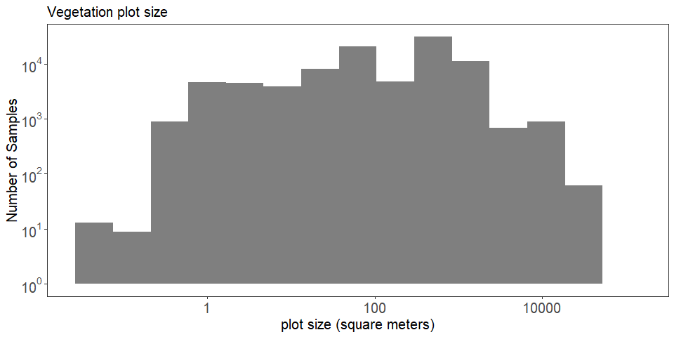

### Sample age

The **VegVault** database deals with both current and paleo data. Therefore, each `Sample` has the indication of *age*, with modern samples being set to 0. To embrace the uncertainty from age-depth modeling paleo-record, the **VegVault** database has a structure to hold an uncertainty matrix containing information about all *potential ages* of each `Sample` from a paleo `Dataset`.

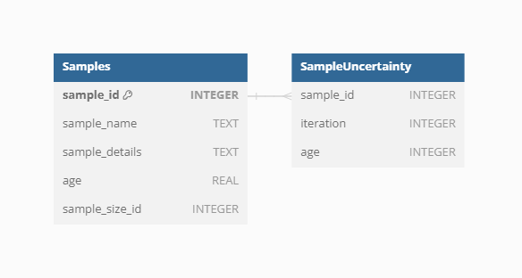

We can show this on the previously selected fossil pollen archive with dataset ID: 91256.

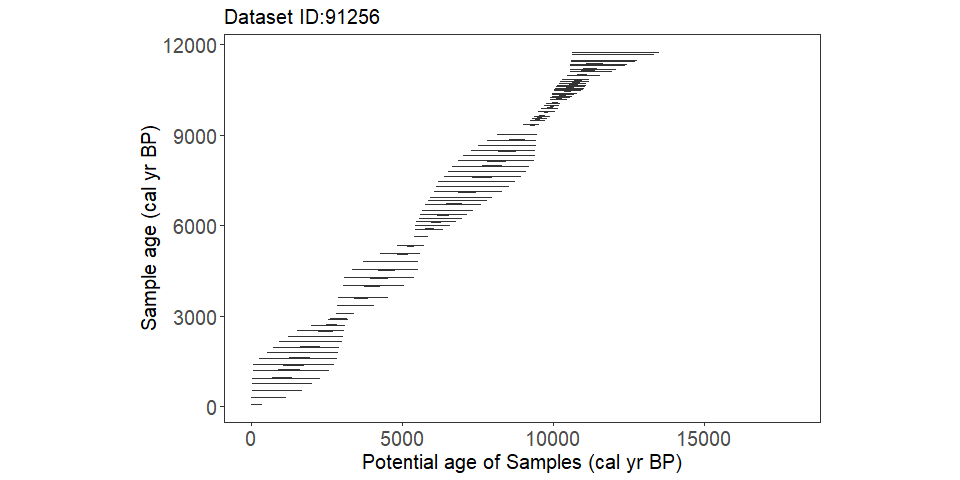

### Sample reference

Individual `Sample` can have specific references on top of the reference to `Dataset`

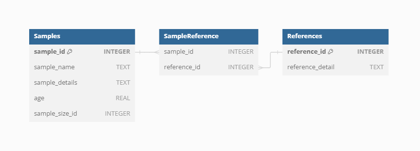

## Taxa

The **VegVault** database contains taxa names directly from main *Data Source-types*.

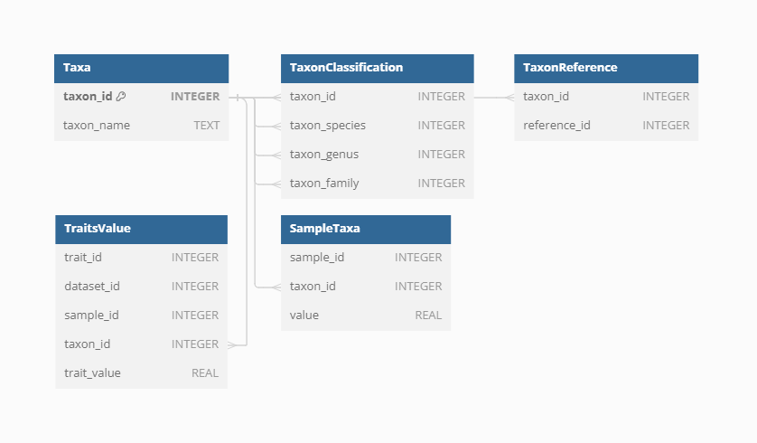

Individual taxa names are linked to the `Samples` by the `SampleTaxa` table.

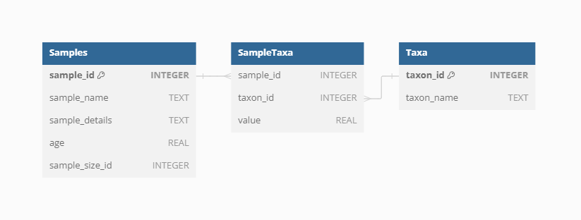

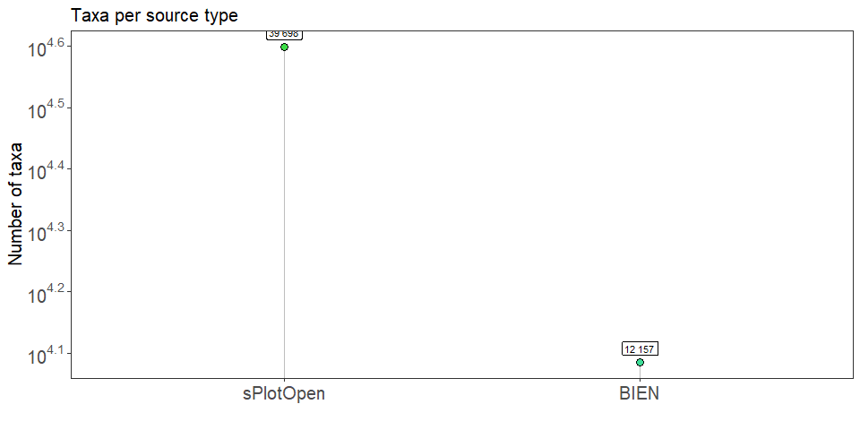

### Classification

In order to obtain classification of all taxa present in the **VegVault** database, the {taxospace} R package has been utilized, automatically aligning the names to [Taxonomy Backbone](https://www.gbif.org/dataset/d7dddbf4-2cf0-4f39-9b2a-bb099caae36c) from [Global Biodiversity Information Facility](https://www.gbif.org/).

Classification up to the family level is then saved for each taxon.

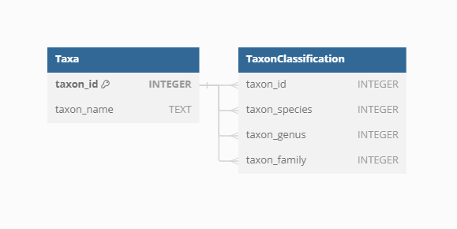

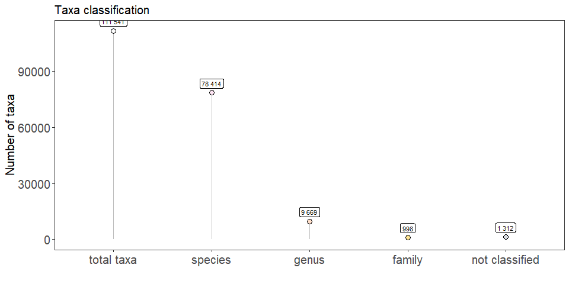